# Plotting NPS Data

A Step-by-Step Walkthrough for Plotting NPS Data using GGPlot

Author: [Chris Mahoney](https://www.linkedin.com/in/chrimaho/)

Published: 29/Jan/2020

# 1 Introduction

The Net Promoter Score (NPS) is a trusted metric used by countless business to decide whether customers are Detractors or Promoters of the business. There is extensive resources online to justify the use of this metric, including on sites such as [qualtrics.com](https://www.qualtrics.com/experience-management/customer/net-promoter-score/), [wikipedia.org](https://en.wikipedia.org/wiki/Net_Promoter) and [netpromoter.com](https://www.netpromoter.com/know/).

The calculation of the NPS value is quite simple: *N**P**S* = %*P**r**o**m**o**t**e**r**s* − %*D**e**t**r**a**c**t**o**r**s*

There are two options that can be used to visualise the NPS Value:

1. First is in the true essence of the metric, which is a bar plot, the the NPS score displayed on the plot.
2. Second is to display a density plot for the data.

This Vignette is provides a helpful guide to visualise the NPS data for both these methods, using [`ggplot2`](https://ggplot2.tidyverse.org/) in the [`R`](https://www.r-project.org/) programming language.

# 2 Set Up

## 2.1 Load the Packages

To begin, the environment must be set up. The first step is to load the packages that will be used.

```r
library(ggplot2)
library(dplyr)
library(magrittr)
library(tidyr)
```

## 2.2 Generate the Data

The next step is to generate the NPS data. For this, the `sample()` function is used to generate $1, 000$ values between $6$ and $10$. The first $20$ values are printed below for convenience.

Noting that this dummy data is generated by using a function. However, this data can be collected from any survey software, and fed in to this data pipeline at this point. The only prerequisite is that the data be a single vector of numbers that are all integers between $0$ and $10$, inclusive.

```r
set.seed(123)
NpsData <- sample(x=6:10, size=1000, replace=TRUE, prob=c(0.06, 0.05, 0.05, 0.42, 0.42))
NpsData %>% head(20) %>% print()
```

```
##  [1]  9 10  9  6  8  9 10  6 10 10  7 10 10 10  9  6  9  9  9  7
```

## 2.3 Check the Data

Next, to confirm that the data looks correct, the descriptive statistics are calculated for the generated data. For this, the `summarise_all()` function is used to calculate some key statistics.

```r
NpsData %>%
    data.frame() %>%
    summarise_all(list(Min=min, Max=max, Mean=mean, `Standard Deviation`=sd, Count=NROW)) %>%
    gather("Statistic", "Value") %>%
    mutate_at("Value", round, 2)
```

| Statistic | Value |
| --- | --- |
| Min | 6.00 |
| Max | 10.00 |
| Mean | 9.09 |
| Standard Deviation | 1.10 |
| Count | 1000.00 |

# 3 Option One: Visualise Bar Plot

## 3.1 Summarise NPS Data

To calculate the NPS score, the following steps are performed on the data:

1. Coerce the data in to a `data.frame`;
2. Add a `Category` variable to determine the category of the score;
3. Count the number of scores in each category;
4. Calculate the percentage of the different categories;
5. Calculate the NPS score; and
6. Coerce it again in to a `data.frame` to add a new variable called `NPS`.

Once generated, the data is ready to be visualised.

```r
NpsScore <- NpsData %>%
    data.frame(Score=.) %>%
    mutate(Category="Promoters"
          ,Category=ifelse(Score<=8, "Passives", Category)
          ,Category=ifelse(Score<=6, "Detractors", Category)
          ,Category=factor(Category, levels=c("Promoters", "Passives", "Detractors"))
          ) %>%
    count(Category, name="Count") %>%
    mutate(Percentage=Count/sum(Count)) %>%
    (function(x){
        Pro <- x %>% filter(Category=="Promoters") %>% select(Percentage) %>% pull()
        Det <- x %>% filter(Category=="Detractors") %>% select(Percentage) %>% pull()
        return((Pro-Det)*10)
    }) %>%
    data.frame(Score=.) %>%
    mutate(Name="NPS")
```

| Score | Name |
| --- | --- |
| 7.86 | NPS |

## 3.2 Generate BarPlot Data Frame

In order to properly visualise the NPS score, an empty data frame is generated, with one row being each of the possible scores. The reason for this is to allow for the Bar Plot to be adequately displayed. The way that this data is generated is by using the `seq()` function to create an ordered sequence of numbers from $0$ to $10$, incrementing by $1$ each time.

```r
NpsFrame <- seq(from=0, to=10, by=1) %>%
    data.frame(NPS=.) %>%
    mutate(Name="NPS"
          ,Category="Promoters"
          ,Category=ifelse(NPS<9,"Passives",Category)
          ,Category=ifelse(NPS<7,"Detractors",Category)
          ,Category=factor(Category, levels=c("Promoters", "Passives", "Detractors"))
          ,NPS=factor(NPS, levels=0:10)
          )
```

| NPS | Name | Category |
| --- | --- | --- |
| 0 | NPS | Detractors |
| 1 | NPS | Detractors |
| 2 | NPS | Detractors |
| 3 | NPS | Detractors |
| 4 | NPS | Detractors |
| 5 | NPS | Detractors |
| 6 | NPS | Detractors |
| 7 | NPS | Passives |
| 8 | NPS | Passives |
| 9 | NPS | Promoters |
| 10 | NPS | Promoters |

## 3.3 Join them all together

Next, the NPS score and the NPS frame are joined together, so that the NPS score is replicated over each line. This is done by using the `left_join()` function, and using `Name` as the joining variable between the two frames.

```r
FinalData <- left_join(x=NpsFrame
                      ,y=NpsScore
                      ,by="Name"
                      )
```

| NPS | Name | Category | Score |
| --- | --- | --- | --- |
| 0 | NPS | Detractors | 7.86 |
| 1 | NPS | Detractors | 7.86 |
| 2 | NPS | Detractors | 7.86 |
| 3 | NPS | Detractors | 7.86 |
| 4 | NPS | Detractors | 7.86 |
| 5 | NPS | Detractors | 7.86 |
| 6 | NPS | Detractors | 7.86 |
| 7 | NPS | Passives | 7.86 |
| 8 | NPS | Passives | 7.86 |
| 9 | NPS | Promoters | 7.86 |
| 10 | NPS | Promoters | 7.86 |

## 3.4 Plot the final output

Finally, the result is plotted using the `ggplot()` function and the following layers: `geom_bar()`, `geom_point()`, and `geom_label()`.

The following steps were followed:

1. Pipe the `FinalData` data frame in to the `ggplot()` function, using the `Name` variable as the sole aesthetic variable.
2. Add a `geom_bar()` layer, using the `Category` variable to determine which colours to use to fill the column, then add a border around the categories using the colour ‘DarkGrey’, and give it a width of $0.5$ units.
3. Add a `geom_point()` layer, using the following arguments:
   1. ‘`data`’ is created using an anonymous function. This is so that the data used by the `ggplot()` function can be manipulated, without using another external variable. The manipulation was effectively used to create a single NPS score which can be used in this layer.
   2. ‘`aes`’ is the aesthetic used for the `y` axis; which in this instance is the NPS score. This is used to determine where on the plot the point should be placed.
   3. ‘`shape`’ is a `plus` symbol, which is used to determine the exact location of the point, as convenient for the human eye to see.
   4. ‘`size`’ is the size of the symbol, which in this instance is $25$ units.
4. Add a `geom_label()` layer, using the following arguments:
   1. ‘`data`’ is again manipulated to determine the same value as used in `geom_point()`.
   2. ‘`stat`’ is the statistic used to calculate the position of the label; which in this instance is the value `identity`, which effectively tells `ggplot` to use the own identity of the data, and not calculate any other statistic for the data.
   3. ‘`aes`’ is used to determine that the `label` should be the value from the `Score` variable, and that it should be placed at the `Score` position on the `y` axis. Effectively, this aesthetic is used to decide *what* the value of the label should be, and *where* it should be place on the plot.
   4. ‘`size`’ is used to determine the size of the label; which in this instance is $5$ units.
5. Determine how many breaks should be used, and the limits of the `y` axis, using the `scale_y_continuous()` layer.
6. Determine the colours that should be used in the three different Categories, using the `scale_fill_manual()` layer.
7. Hide the axis text for the `y` axis, using the `axis.text.y.left` argument of the `theme()` layer.
8. Flip the coordinates of the plot, so that it appears to be a bar from left to right, using the `coord_flip()` layer.
9. Label the axes, using the `labs()` layer, to ensure that the correct information is displayed in the correct positions.

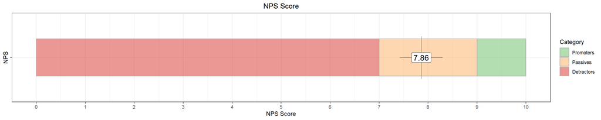

```r
FinalData %>%
    ggplot(aes(Name)) +
    geom_bar(aes(fill=Category), colour="darkgrey", width=0.5, alpha=0.5) +
    geom_point(data=function(x) {x <- x %>% select(Name, Score) %>% mutate(Score=round(Score,2)) %>% distinct()}
              ,stat="identity"
              ,aes(y=Score)
              ,shape="plus"
              ,size=25
              ) +
    geom_label(data=function(x) {x %>% select(Name, Score) %>% mutate(Score=round(Score,2)) %>% distinct}
              ,stat="identity"
              ,aes(y=Score, label=Score)
              ,size=5
              ) +
    scale_y_continuous(breaks=seq(0,10,1), limits=c(0,10), oob=squish) +
    scale_fill_manual(values=c("#66bd63", "#fdae61", "#d73027")) +
    theme(axis.text.y.left=element_blank()) +
    coord_flip() +
    labs(title="NPS Score"
        ,fill="Category"
        ,y="NPS Score"
        ,x="NPS"
        )
```

# 4 Option Two: Visualise Density Plot

## 4.1 Generate DensityPlot Data Frame

In order to visualise the Density Plot, the data does not need to be summarised, but it is better to remain in its raw form. It does, however, need to undergo the following manipulations:

1. Coerce in to a `data.frame`; and
2. Add the `Category` variable.

```r
FinalFrame <- NpsData %>%
    data.frame(Score=.) %>%
    mutate(Category="Promoters"
          ,Category=ifelse(Score<=8, "Passives", Category)
          ,Category=ifelse(Score<=6, "Detractors", Category)
          ,Category=factor(Category, levels=c("Promoters", "Passives", "Detractors"))
          )
```

| Score | Category |
| --- | --- |
| 9 | Promoters |
| 10 | Promoters |
| 9 | Promoters |
| 6 | Detractors |
| 8 | Passives |
| 9 | Promoters |
| 10 | Promoters |
| 6 | Detractors |
| 10 | Promoters |
| 10 | Promoters |

## 4.2 Visualise the DensityPlot data

Once the Density data frame is generated, it can be visualised through `ggplot()`, using the following aesthetics: `geom_bar()` and `geom_density()`.

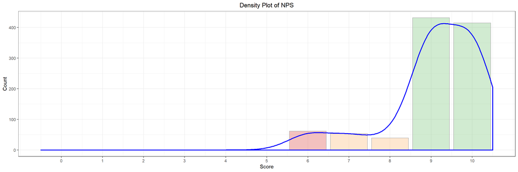

```r
FinalFrame %>%
    ggplot(aes(Score)) +
    geom_bar(aes(fill=Category), colour="darkgrey", alpha=0.3) +
    geom_density(aes(y=..count..), colour="blue", adjust=3, size=1) +
    scale_fill_manual(values=c("#66bd63", "#fdae61", "#d73027")) +
    scale_x_continuous(breaks=seq(0,10,1), limits=c(-0.5,10.5)) +
    theme(legend.position="none") +
    labs(title="Density Plot of NPS"
        ,x="Score"
        ,y="Count"
        )
```

# 5 Conclusion

As seen, the Net Promoter Score is a useful metric to see the percentage of customers who are Promoters, Passives or Detractors of the business. This metric can be visualised in a simple BarPlot, with a static value displayed on the chart, or it can be visualised as a DensityPlot, showing the proportion of customers in the different categories. Both of these methodologies are provided in this Vignette, with a step-by-step guide from data manipulation to plotting.

# 6 Post Script

**Publications**: This report is also published on the following sites:

1. RPubs: [RPubs/chrimaho/PlottingNPS](http://rpubs.com/chrimaho/PlottingNPS)
2. GitHub: [GitHub/chrimaho/PlottingNPS](https://github.com/chrimaho/PlottingNPS)
3. Medium: [Medium/chrimaho/PlottingNPS](https://medium.com/@chrimaho/plottingnps-2958b642a51f?source=friends_link&sk=382557ae6dd6227d004eb42a374fbb8f)

**Change Log:** This publication was modified on the following dates:

1. 29/Jan/2020: Original Publication Date

Report compiled by [Chris Mahoney](https://www.linkedin.com/in/chrimaho/)

*chrismahoney@hotmail.com*